# Williams Wet Tropics Vertebrate dataset

Arun Singh Ramesh[^1]

29/09/2023

## EcoPlots API example

The example code shown here is designed to give you an experience at downloading, analyzing and visualising a dataset that is archived on the TERN EcoPlots https://ecoplots.tern.org.au/. EcoPlots contains plot-based ecology data from different sources to enable integrated search and access to data based on different jurisdiction, data sources, feature types, parameters and temporal extent.

# General preparations

### Set your working directory

This gets you started with storing your files and r scripts.

```r
#setwd("C:/Users/uqasin21") # Note that your path will be different
```

### Load libraries

If you do not have the following packages downloaded, you can install them using the function `install.packages`, with the name of the package as an argument in quotations.

```r
library(tidyverse)
library(httr)
library(ggpubr)
```

# Load and explore the data

At this point, you should have your Ecoplots search query from the EcoPlots API Query dash board (https://ecoplots-test.tern.org.au/discovery).

*Important* Make sure to download your API key from the website (https://account-test.tern.org.au/authenticated_user/apikeys) Once you have your API code extracted you can start using the query request

In the following example I have used the Ecoplots-test version (https://ecoplots-test.tern.org.au/api/v1.0/data/bdbsa?dformat=geojson). Please make sure to use the latest version of Ecoplots on the following link: https://ecoplots.tern.org.au/

# Explore your data frame and do simple stats

First step is to create a data frame, explore and organise it to suite your research needs. In this example file, we have occurrence of vertebrates from the Australian Wet Tropics Bioregion, compiled by Williams, 2006.

```r
#create a data frame from the API response
df<-read.table(text = content(res, 'text'), sep =",", header = TRUE, stringsAsFactors = FALSE)
```

```r
#data exploration and wrangling
head(df)
```

|  | datasetTitle | siteName | parentSiteName | latitude_Degree | longitude_Degree | featureType | featureId | scientificName | scientificName.1 | scientificNameResultTime | scientificNameMethod | regionalGovermentConservationStatus | regionalGovermentConservationStatusResultTime | regionalGovermentConservationStatusMethod |
| --- | --- | --- | --- | --- | --- | --- | --- | --- | --- | --- | --- | --- | --- | --- |
| 1 | Williams Wet Tropics Vertebrate database | NA | N/A | -17.40972 | 145.9808 | animal occurrence | http://linked.data.gov.au/dataset/wet-tropics-vertebrate/animal_occurr_id-misc-1 | Casuarius casuarius johnsonii | Casuarius casuarius johnsonii | 2001-05-01T00:00:00 | http://linked.data.gov.au/def/tern-cv/de94b8fd-5c66-4338-9652-535c8610458f | Endangered wildlife | 2001-05-01T00:00:00 | http://linked.data.gov.au/def/tern-cv/de94b8fd-5c66-4338-9652-535c8610458f |
| 2 | Williams Wet Tropics Vertebrate database | NA | N/A | -16.06932 | 145.4621 | animal occurrence | http://linked.data.gov.au/dataset/wet-tropics-vertebrate/animal_occurr_id-misc-10 | Casuarius casuarius johnsonii | Casuarius casuarius johnsonii | 2007-01-19T00:00:00 | http://linked.data.gov.au/def/tern-cv/de94b8fd-5c66-4338-9652-535c8610458f | Endangered wildlife | 2007-01-19T00:00:00 | http://linked.data.gov.au/def/tern-cv/de94b8fd-5c66-4338-9652-535c8610458f |
| 3 | Williams Wet Tropics Vertebrate database | NA | N/A | -17.51540 | 145.5126 | animal occurrence | http://linked.data.gov.au/dataset/wet-tropics-vertebrate/animal_occurr_id-misc-100 | Casuarius casuarius johnsonii | Casuarius casuarius johnsonii | 1996-06-01T00:00:00 | http://linked.data.gov.au/def/tern-cv/de94b8fd-5c66-4338-9652-535c8610458f | Endangered wildlife | 1996-06-01T00:00:00 | http://linked.data.gov.au/def/tern-cv/de94b8fd-5c66-4338-9652-535c8610458f |
| 4 | Williams Wet Tropics Vertebrate database | NA | N/A | -17.85590 | 146.0609 | animal occurrence | http://linked.data.gov.au/dataset/wet-tropics-vertebrate/animal_occurr_id-misc-1000 | Casuarius casuarius johnsonii | Casuarius casuarius johnsonii | 1997-07-21T00:00:00 | http://linked.data.gov.au/def/tern-cv/de94b8fd-5c66-4338-9652-535c8610458f | Endangered wildlife | 1997-07-21T00:00:00 | http://linked.data.gov.au/def/tern-cv/de94b8fd-5c66-4338-9652-535c8610458f |
| 5 | Williams Wet Tropics Vertebrate database | NA | N/A | -17.25417 | 145.6375 | animal occurrence | http://linked.data.gov.au/dataset/wet-tropics-vertebrate/animal_occurr_id-misc-10007 | Podiceps cristatus australis | Podiceps cristatus australis | 1993-07-01T00:00:00 | http://linked.data.gov.au/def/tern-cv/de94b8fd-5c66-4338-9652-535c8610458f | N/A | N/A | N/A |
| 6 | Williams Wet Tropics Vertebrate database | NA | N/A | -17.85590 | 146.0609 | animal occurrence | http://linked.data.gov.au/dataset/wet-tropics-vertebrate/animal_occurr_id-misc-1001 | Casuarius casuarius johnsonii | Casuarius casuarius johnsonii | 1997-07-18T00:00:00 | http://linked.data.gov.au/def/tern-cv/de94b8fd-5c66-4338-9652-535c8610458f | Endangered wildlife | 1997-07-18T00:00:00 | http://linked.data.gov.au/def/tern-cv/de94b8fd-5c66-4338-9652-535c8610458f |

```r
tail(df)
```

|  | datasetTitle | siteName | parentSiteName | latitude_Degree | longitude_Degree | featureType | featureId | scientificName | scientificName.1 | scientificNameResultTime | scientificNameMethod | regionalGovermentConservationStatus | regionalGovermentConservationStatusResultTime | regionalGovermentConservationStatusMethod |
| --- | --- | --- | --- | --- | --- | --- | --- | --- | --- | --- | --- | --- | --- | --- |
| 244059 | Williams Wet Tropics Vertebrate database | NA | N/A | -18.15033 | 145.6961 | animal occurrence | http://linked.data.gov.au/dataset/wet-tropics-vertebrate/animal_occurr_id-std-99994 | Colluricincla (Myiolestes) boweri | Colluricincla (Myiolestes) boweri | 2004-03-28T00:00:00 | http://linked.data.gov.au/def/tern-cv/5c74f891-f6f5-4887-bbdb-6b619a6822d3 | Least concern wildlife | 2004-03-28T00:00:00 | http://linked.data.gov.au/def/tern-cv/de94b8fd-5c66-4338-9652-535c8610458f |
| 244060 | Williams Wet Tropics Vertebrate database | NA | N/A | -17.62081 | 145.6706 | animal occurrence | http://linked.data.gov.au/dataset/wet-tropics-vertebrate/animal_occurr_id-std-99995 | Colluricincla (Myiolestes) boweri | Colluricincla (Myiolestes) boweri | 2004-05-13T00:00:00 | http://linked.data.gov.au/def/tern-cv/5c74f891-f6f5-4887-bbdb-6b619a6822d3 | Least concern wildlife | 2004-05-13T00:00:00 | http://linked.data.gov.au/def/tern-cv/de94b8fd-5c66-4338-9652-535c8610458f |
| 244061 | Williams Wet Tropics Vertebrate database | NA | N/A | -18.15059 | 145.6943 | animal occurrence | http://linked.data.gov.au/dataset/wet-tropics-vertebrate/animal_occurr_id-std-99996 | Colluricincla (Myiolestes) boweri | Colluricincla (Myiolestes) boweri | 2004-03-28T00:00:00 | http://linked.data.gov.au/def/tern-cv/5c74f891-f6f5-4887-bbdb-6b619a6822d3 | Least concern wildlife | 2004-03-28T00:00:00 | http://linked.data.gov.au/def/tern-cv/de94b8fd-5c66-4338-9652-535c8610458f |
| 244062 | Williams Wet Tropics Vertebrate database | NA | N/A | -17.61554 | 145.6673 | animal occurrence | http://linked.data.gov.au/dataset/wet-tropics-vertebrate/animal_occurr_id-std-99997 | Colluricincla (Myiolestes) boweri | Colluricincla (Myiolestes) boweri | 2004-05-13T00:00:00 | http://linked.data.gov.au/def/tern-cv/5c74f891-f6f5-4887-bbdb-6b619a6822d3 | Least concern wildlife | 2004-05-13T00:00:00 | http://linked.data.gov.au/def/tern-cv/de94b8fd-5c66-4338-9652-535c8610458f |
| 244063 | Williams Wet Tropics Vertebrate database | NA | N/A | -17.61554 | 145.6673 | animal occurrence | http://linked.data.gov.au/dataset/wet-tropics-vertebrate/animal_occurr_id-std-99998 | Colluricincla (Myiolestes) boweri | Colluricincla (Myiolestes) boweri | 2004-05-13T00:00:00 | http://linked.data.gov.au/def/tern-cv/5c74f891-f6f5-4887-bbdb-6b619a6822d3 | Least concern wildlife | 2004-05-13T00:00:00 | http://linked.data.gov.au/def/tern-cv/de94b8fd-5c66-4338-9652-535c8610458f |
| 244064 | Williams Wet Tropics Vertebrate database | NA | N/A | -18.15033 | 145.6961 | animal occurrence | http://linked.data.gov.au/dataset/wet-tropics-vertebrate/animal_occurr_id-std-99999 | Colluricincla (Myiolestes) boweri | Colluricincla (Myiolestes) boweri | 2004-03-28T00:00:00 | http://linked.data.gov.au/def/tern-cv/5c74f891-f6f5-4887-bbdb-6b619a6822d3 | Least concern wildlife | 2004-03-28T00:00:00 | http://linked.data.gov.au/def/tern-cv/de94b8fd-5c66-4338-9652-535c8610458f |

We need to store the scientific name and regional government conservation status as a factor.

```r
#data exploration and wrangling
df$scientificName<- as.factor(df$scientificName)
df$regionalGovermentConservationStatus<- as.factor(df$regionalGovermentConservationStatus)

summary(df$regionalGovermentConservationStatus)
```

```
##    Critically endangered      Endangered wildlife      Extinct in the wild
##                     4560                     6627                      734
##   Least concern wildlife                      N/A Near threatened wildlife
##                   122718                   104030                     2023
##    Special least concern      Vulnerable wildlife
##                     1662                     1710
```

# Data wrangling and Visualisation-1: Conservation Status

Let us visualize them and plot on a map to see how they are distributed within the bioregion.

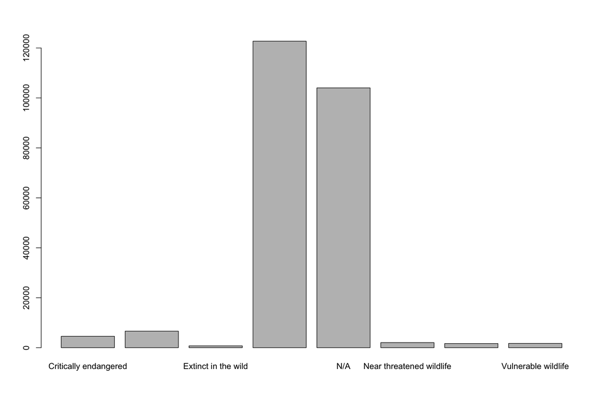

```r
#data exploration and wrangling
plot(df$regionalGovermentConservationStatus)
```

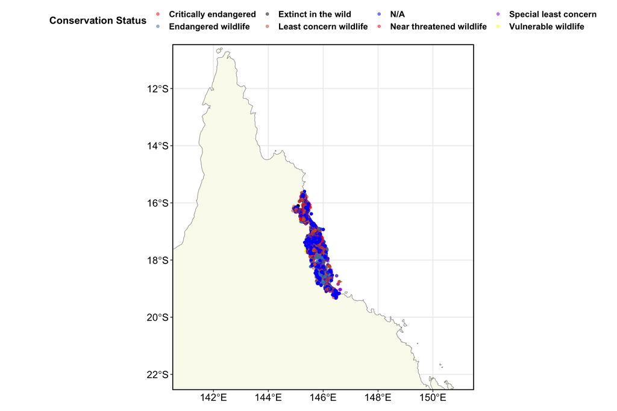

```r
#mapping
# Map
library(ozmaps)
library(sf)
aus <- ozmap_data(data = "states") # create a map layer with state boundaries

#Map based on Conservation status
m1<- ggplot() +
  geom_sf(data = aus, fill = "#FBFBEF") +
  geom_point(
    data = df,
    mapping = aes(
      x = longitude_Degree,
      y = latitude_Degree,
      colour = regionalGovermentConservationStatus),
    alpha = 0.5)+
  theme_void() +
  coord_sf(ylim = c(-11, -22),
           xlim = c(141, 151))+ labs(x = expression(""), y = expression(""), colour="Conservation Status")+ theme_bw()

m1+ scale_color_manual(values=c("red", "steelblue", "grey2", "#CE5832", "blue", "red", "purple", "yellow"))+theme(axis.text.y = element_text(colour = "black", size = 14, face = "bold"),
          axis.text.x = element_text(colour = "black", face = "bold", size = 14),
          legend.text = element_text(size = 12, face ="bold", colour ="black"),
          legend.position = "top", axis.title.y = element_text(face = "bold", size = 14),
          axis.title.x = element_text(face = "bold", size = 14, colour = "black"),
          legend.title = element_text(size = 14, colour = "black", face = "bold"),
          panel.background = element_blank(), panel.border = element_rect(colour = "black", fill = NA, size = 1.2),
          legend.key=element_blank())
```

#Data wrangling and Visualisation-2: Species counts

Let us create a new data frame with count of species occurrences and conservation status and visualize the levels of occurrence.

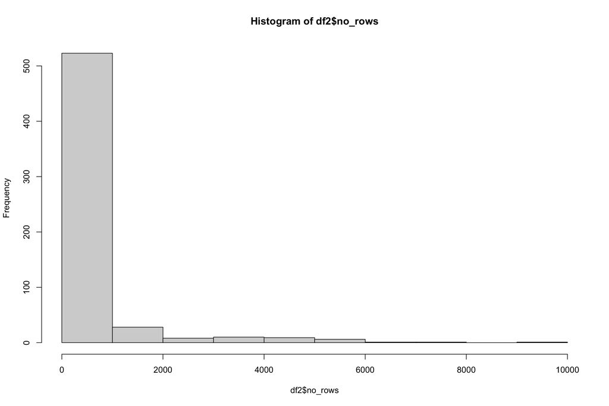

```r
df2<- df%>% group_by(scientificName, regionalGovermentConservationStatus) %>%
  summarise(no_rows = length(scientificName))

hist(df2$no_rows)
```

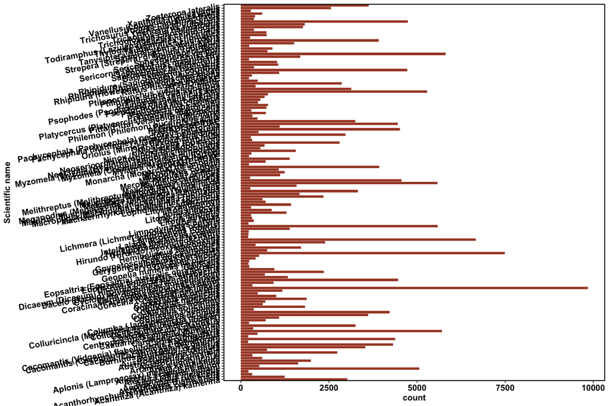

```r
# high species occurrence ones
df3<- df2 %>% filter(no_rows > 200)

h1<- ggplot(df3, aes(x=no_rows, y=scientificName))+
  geom_bar(stat = 'identity', fill = "#a84830")+theme(axis.text.y = element_text(angle = 10, hjust = 1))+labs(y="Scientific name",x="count")

h1+ theme(axis.text.y = element_text(colour = "black", size = 12, face = "bold"),
          axis.text.x = element_text(colour = "black", face = "bold", size = 12),
          legend.text = element_text(size = 12, face ="bold", colour ="black"),
          legend.position = "none", axis.title.y = element_text(face = "bold", size = 12),
          axis.title.x = element_text(face = "bold", size = 12, colour = "black"),
          legend.title = element_text(size = 12, colour = "black", face = "bold"),
          panel.background = element_blank(), panel.border = element_rect(colour = "black", fill = NA, size = 1.2),
          legend.key=element_blank())
```

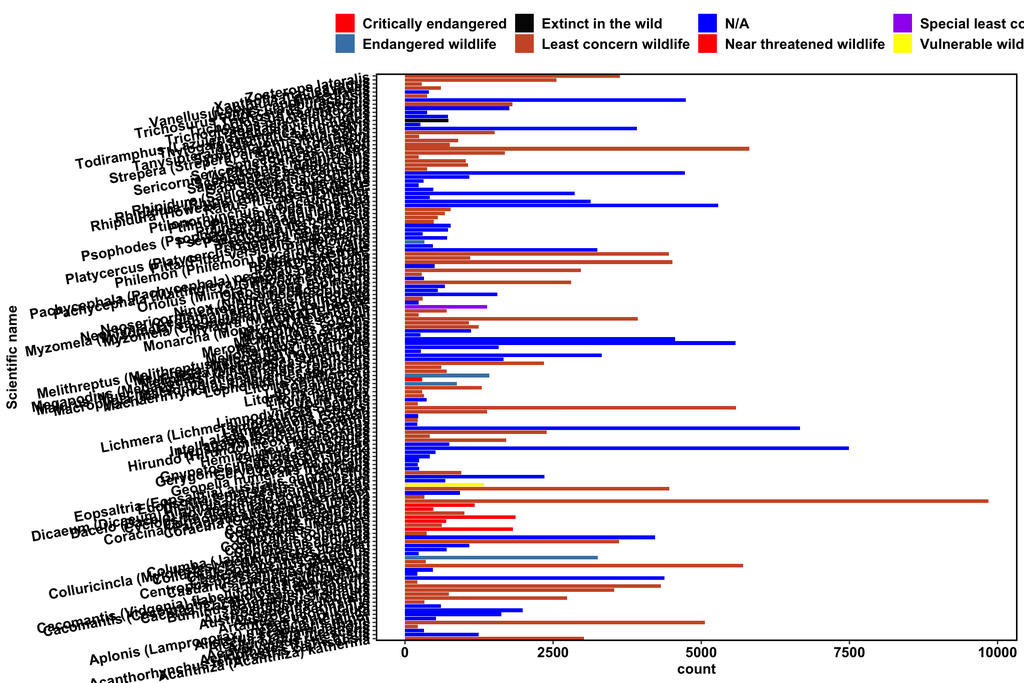

```r
#let us fill this with the conservation status
h2<- ggplot(df3, aes(x=no_rows, y=scientificName, fill=regionalGovermentConservationStatus))+
  geom_bar(stat = 'identity')+theme(axis.text.y = element_text(angle = 10, hjust = 1))+labs(y="Scientific name",x="count", fill="")

h2+ scale_fill_manual(values=c("red", "steelblue", "grey2", "#CE5832", "blue", "red", "purple", "yellow"))+theme(axis.text.y = element_text(colour = "black", size = 12, face = "bold"),
          axis.text.x = element_text(colour = "black", face = "bold", size = 12),
          legend.text = element_text(size = 12, face ="bold", colour ="black"),
          legend.position = "top", axis.title.y = element_text(face = "bold", size = 12),
          axis.title.x = element_text(face = "bold", size = 12, colour = "black"),
          legend.title = element_text(size = 12, colour = "black", face = "bold"),
          panel.background = element_blank(), panel.border = element_rect(colour = "black", fill = NA, size = 1.2),
          legend.key=element_blank())
```

We observe that there are not many endangered species (other than *Casuarius casuarius johnsonii* ) in this smaller dataset with species counts of >200.

Let us see how many species are present with really low counts.

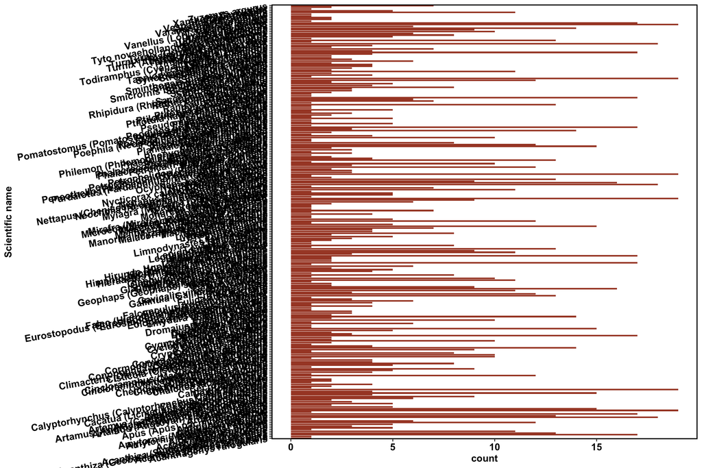

```r
# high species occurrence ones
lowcounts<- df2 %>% filter(no_rows < 20)


l1<- ggplot(lowcounts, aes(x=no_rows, y=scientificName))+
  geom_bar(stat = 'identity', fill = "#a84830")+theme(axis.text.y = element_text(angle = 10, hjust = 1))+labs(y="Scientific name",x="count")

l1+ theme(axis.text.y = element_text(colour = "black", size = 12, face = "bold"),
          axis.text.x = element_text(colour = "black", face = "bold", size = 12),
          legend.text = element_text(size = 12, face ="bold", colour ="black"),
          legend.position = "none", axis.title.y = element_text(face = "bold", size = 12),
          axis.title.x = element_text(face = "bold", size = 12, colour = "black"),
          legend.title = element_text(size = 12, colour = "black", face = "bold"),
          panel.background = element_blank(), panel.border = element_rect(colour = "black", fill = NA, size = 1.2),
          legend.key=element_blank())
```

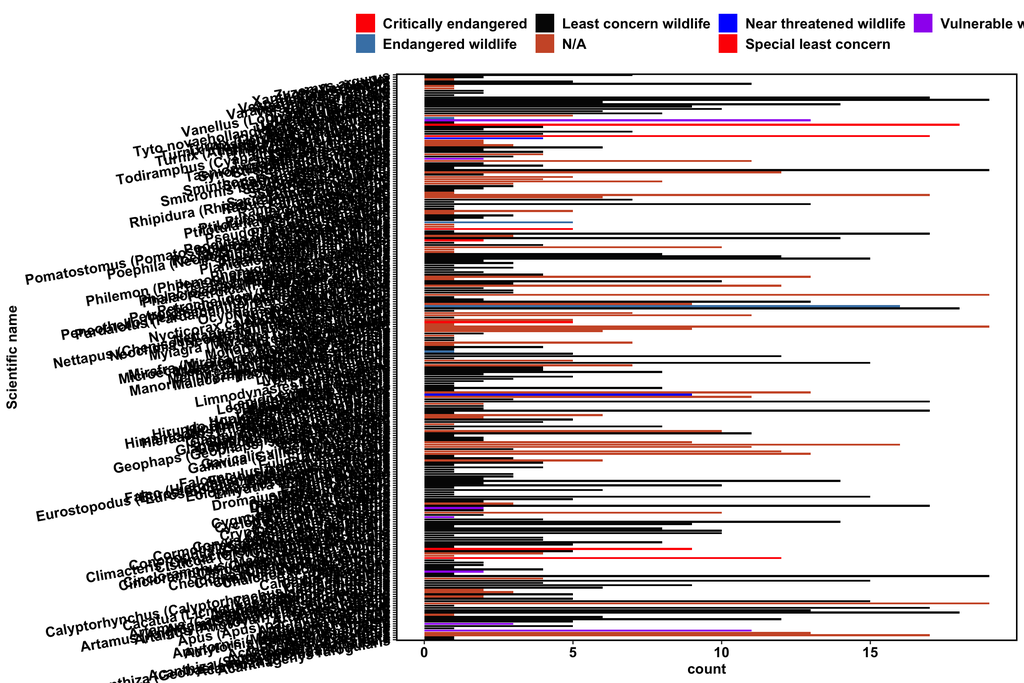

```r
#let us fill this with the conservation status
l2<- ggplot(lowcounts, aes(x=no_rows, y=scientificName, fill=regionalGovermentConservationStatus))+
  geom_bar(stat = 'identity')+theme(axis.text.y = element_text(angle = 10, hjust = 1))+labs(y="Scientific name",x="count", fill="")

l2+ scale_fill_manual(values=c("red", "steelblue", "grey2", "#CE5832", "blue", "red", "purple", "yellow"))+theme(axis.text.y = element_text(colour = "black", size = 12, face = "bold"),
          axis.text.x = element_text(colour = "black", face = "bold", size = 12),
          legend.text = element_text(size = 12, face ="bold", colour ="black"),
          legend.position = "top", axis.title.y = element_text(face = "bold", size = 12),
          axis.title.x = element_text(face = "bold", size = 12, colour = "black"),
          legend.title = element_text(size = 12, colour = "black", face = "bold"),
          panel.background = element_blank(), panel.border = element_rect(colour = "black", fill = NA, size = 1.2),
          legend.key=element_blank())
```

As you can see that majority of the dataset contains low counts from Least Concern wildlife.

```r
# make a data frame with high and low occurrence to map
df5<- df%>% group_by(scientificName, regionalGovermentConservationStatus) %>%
  reframe(count = length(scientificName),
                             latitude=latitude_Degree,
                             longitude=longitude_Degree)

# Creating a factor corresponding to species distribution counts with labels
df5$occurrence = cut(df5$count, 3, labels=c('Low', 'Medium', 'High'))
table(df5$occurrence)
```

```
##
##    Low Medium   High
## 124718  95345  24001
```

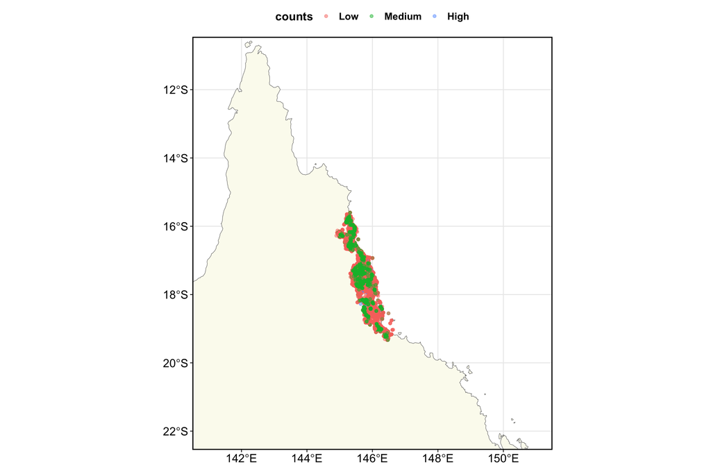

```r
#Map based on proportional count status
m1<- ggplot() +
  geom_sf(data = aus, fill = "#FBFBEF") +
  geom_point(
    data = df5,
    mapping = aes(
      x = longitude,
      y = latitude,
      colour = occurrence),
    alpha = 0.5)+
  theme_void() +
  coord_sf(ylim = c(-11, -22),
           xlim = c(141, 151))+ labs(x = expression(""), y = expression(""), colour="counts")+ theme_bw()

m1+ scale_fill_manual(values=c("red", "steelblue", "grey2", "#CE5832", "blue", "red", "purple", "yellow"))+
theme(axis.text.y = element_text(colour = "black", size = 14, face = "bold"),
axis.text.x = element_text(colour = "black", face = "bold", size = 14),
legend.text = element_text(size = 12, face ="bold", colour ="black"),
legend.position = "top", axis.title.y = element_text(face = "bold", size = 14),
axis.title.x = element_text(face = "bold", size = 14, colour = "black"),
legend.title = element_text(size = 14, colour = "black", face = "bold"),
panel.background = element_blank(), panel.border = element_rect(colour = "black", fill = NA, size = 1.2),
legend.key=element_blank())
```

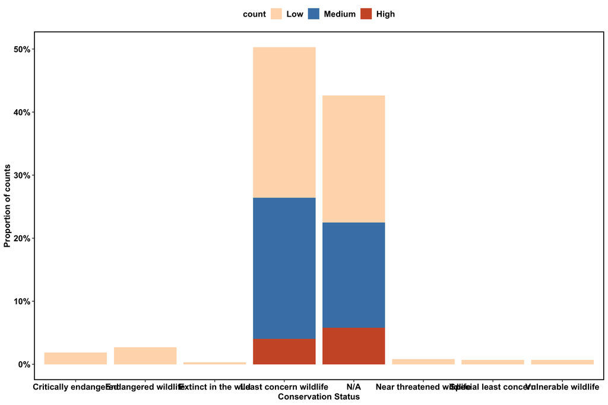

```r
#Plotting the proportion of occurrence counts for each Conservation Status

b1<- ggplot(df5, aes(x = regionalGovermentConservationStatus, fill = occurrence)) +
  geom_bar(aes(y = after_stat(count / sum(count)))) +
  scale_y_continuous(labels = scales::percent)+labs(y="Proportion of counts",x="Conservation Status", fill="count")

b1+scale_fill_manual(values=c("peachpuff", "steelblue", "#CE5832", "blue", "red", "purple", "yellow"))+
  theme(axis.text.y = element_text(colour = "black", size = 12, face = "bold"),
axis.text.x = element_text(colour = "black", face = "bold", size = 12),
legend.text = element_text(size = 12, face ="bold", colour ="black"),
legend.position = "top", axis.title.y = element_text(face = "bold", size = 12),
axis.title.x = element_text(face = "bold", size = 12, colour = "black"),
legend.title = element_text(size = 12, colour = "black", face = "bold"),
panel.background = element_blank(), panel.border = element_rect(colour = "black", fill = NA, size = 1.2),
legend.key=element_blank())
```

# Summary

- We extracted a response using an API query for the Williams Wet Tropics dataset example from the TERN EcoPlots
- We observed using simple steps how we can extract information of species occurrence.
- We found how the dataset was accounted for differences in species and their conservation status and we finally visualised them on a map.

# References

1. [TERN EcoPlots- Terrestrial Ecosystem Research Network.](https://ecoplots.tern.org.au/)
2. [Vertebrates of the Wet Tropics Rainforests of Australia: Species Distributions and Biodiversity.Cooperative Research Centre for tropical Rainforest Ecology and Management. Rainforest CRC, Cairns, Australia (282 pp.)](https://rainforest-crc.jcu.edu.au/publications/vertebrate_distributions_full.pdf)

# Cite this example

This example is licensed under the Creative Commons Attribution 4.0 (CC-BY-4.0)

You can cite this example dataset for your research as: Singh Ramesh, A. 2023. An example to query an API request for CSV files from the TERN EcoPlots (Williams Wet Tropics Dataset).https://ternaustralia.github.io/ecoplots-examples/

[^1]: TERN, a.singhramesh@uq.edu.au